# AGEC 936 - Module 1

Panel Data Analysis

Jisang Yu  
Kansas State University

# Panel data: an introduction

- Data structure

$$Y=\begin{pmatrix}y_{11} & y_{21} & ... & y_{N1} \\
y_{12} & y_{22} & ... & y_{N2} \\
. & . & ... & . \\
. & . & ... & . \\
. & . & ... & . \\
y_{1T} & y_{2T} & ... & y_{NT}
\end{pmatrix},
\;\;\; D=\begin{pmatrix}d_{11} & d_{21} & ... & d_{N1} \\
d_{12} & d_{22} & ... & d_{N2} \\
. & . & ... & . \\
. & . & ... & . \\
. & . & ... & . \\
d_{1T} & d_{2T} & ... & d_{NT}
\end{pmatrix}$$

- Consider the following data generating process:

$$\begin{align}
y_{it}=\alpha+\rho d_{it}+\varepsilon_{it}
\end{align}$$
$$\begin{align}
\varepsilon_{it}=\gamma x_i + u_{it}
\end{align}$$

- A quick review question: Under what condition we face an **omitted variable bias**?

# A simple simulation: Set up

- Set-up:
  $$\begin{align}
  y_{it}=0.5+10
  d_{it}+0.2x^2_{i}+u_{it}\;\;\text{with}\;\;i=\{1,2,...,500\}\;\;\text{and}\;\;t=\{1,2\}
  \end{align}$$
  $$\begin{align}
  d_{it}= \begin{cases}
  1\;\;\text{if}\;\;x_{i}>5.5\;\;\text{and}\;\;t=2 \\
  0\;\;\text{otherwise}
  \end{cases}
  \end{align}$$
  $$\begin{align}
  x_{i}\;\sim\;U(1,10),\;\;\text{and}\;\;u_{it}\;\sim\;N(0,1)
  \end{align}$$

```stata
clear all
set more off
set obs 500

*Generate panel data
set seed 1234
gen id=_n
gen x=runiform(1,10)
expand 2
bys id: gen t=_n

*DGP
gen d=0
replace d=1 if x>5.5 & t==2
gen e=rnormal()
gen y=0.5+10*d+0.2*(x^2)+e
```

# Some graphical illustrations of the problem

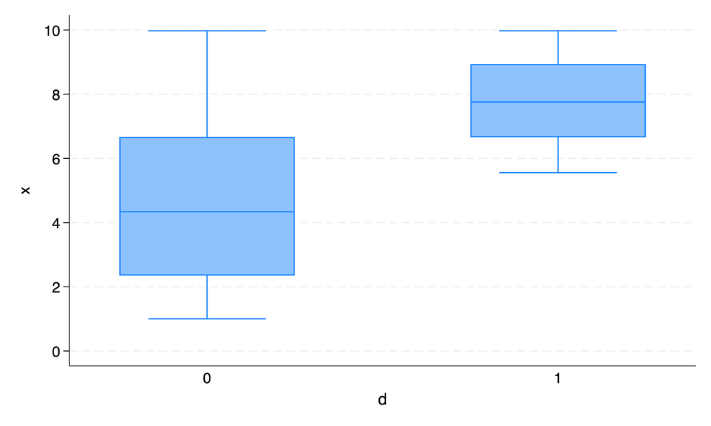

```stata
*graph x by d
graph box x, over(d) graphregion(color(white)) b1title(d)
graph export "selection.png", replace
```

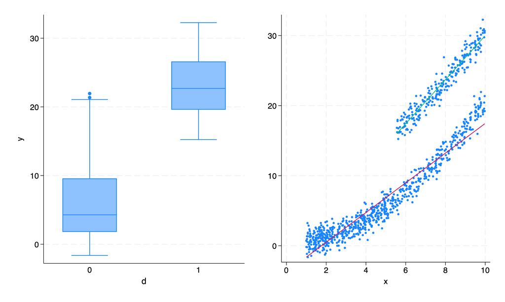

```stata
*graph y by d
graph box y, over(d) graphregion(color(white)) b1title(d) saving(overall.gph, replace)
*graph y on x
gr twoway (sc y x, msize(vsmall)) (lfit y x if d==0) (lfit y x if d==1), graphregion(color(white)) legend(off) saving(ovb.gph, replace)
graph combine overall.gph ovb.gph, col(2) graphregion(color(white))
graph export "ovb.png", replace
rm overall.gph
rm ovb.gph
```

# Pooled OLS

```stata
*regression: pooled OLS
reg y d x
reg y d
```

```
      Source |       SS           df       MS      Number of obs   =     1,000
-------------+----------------------------------   F(2, 997)       =  15519.64
       Model |  79305.6099         2   39652.805   Prob > F        =    0.0000
    Residual |  2547.34245       997  2.55500748   R-squared       =    0.9689
-------------+----------------------------------   Adj R-squared   =    0.9688
       Total |  81852.9524       999  81.9348873   Root MSE        =    1.5984

------------------------------------------------------------------------------
           y | Coefficient  Std. err.      t    P>|t|     [95% conf. interval]
-------------+----------------------------------------------------------------
           d |   10.02567   .1344228    74.58   0.000     9.761882    10.28945
           x |   2.201284    .021874   100.63   0.000     2.158359    2.244208
       _cons |  -4.125397    .118328   -34.86   0.000    -4.357598   -3.893197
------------------------------------------------------------------------------

      Source |       SS           df       MS      Number of obs   =     1,000
-------------+----------------------------------   F(1, 998)       =   1876.07
       Model |  53430.1492         1  53430.1492   Prob > F        =    0.0000
    Residual |  28422.8032       998  28.4797627   R-squared       =    0.6528
-------------+----------------------------------   Adj R-squared   =    0.6524
       Total |  81852.9524       999  81.9348873   Root MSE        =    5.3366

------------------------------------------------------------------------------
           y | Coefficient  Std. err.      t    P>|t|     [95% conf. interval]
-------------+----------------------------------------------------------------
           d |   16.81406   .3881929    43.31   0.000     16.05229    17.57583
       _cons |   6.226367   .1952576    31.89   0.000     5.843205     6.60953
------------------------------------------------------------------------------
```

# Panel Fixed effects approach

- Mundlak (1961): Farm output example – managerial bias

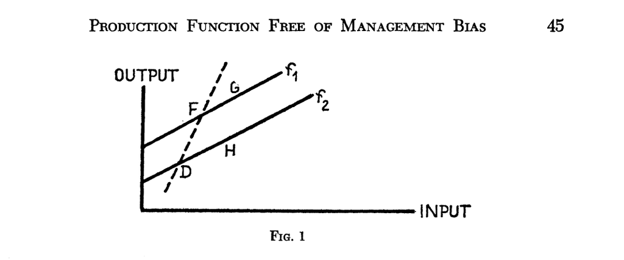

- From the DGP, we have
  $$\begin{align}
  y_{it}=\alpha+\rho d_{it}+f(x_i) + u_{it}
  \end{align}$$
  which can be rewritten as
  $$\begin{align}
  y_{it}=\alpha+\rho d_{it}+v_i + u_{it} \tag{1}
  \end{align}$$
  A quick insight: The functional form of $f$ does not matter as long as its argument is a time-invariant variable specific to each cross-sectional unit. We can always replace $f(x_i)$ with $v_i$. *But, how about the functional form of $y$ itself? (Imai and Kim 2019, AJPS)*
- **Least Squares Dummy Variable (LSDV)** estimator:
  $$\begin{align}
  y_{it}=\alpha+\rho d_{it}+\sum_i c_i I_i + u_{it}
  \end{align}$$
  where $I_i$ is the indicator variables for each cross-sectional unit. Estimate this equation by OLS.
- **Within/Fixed Effects (FE)** estimator:
  $$\begin{align}
  y_{it}-\bar{y}_{i}=\rho (d_{it}-\bar{d}_{i})+ u_{it} \tag{2}
  \end{align}$$
  where
  $$\begin{align}
  \bar{y}_{i}=\alpha+\rho\bar{d}_{i}+v_i+ \bar{u}_{i}. \tag{3}
  \end{align}$$
  with $\bar{x}_{i}=\frac{1}{T}\sum_t x_{i}$. Note that equation (3) is the **within** average of equation (1) (i.e. average over $t$ within $i$) and equation (2) is equation (1) minus equation (3).
- **LSDV** vs **FE**
  - Two estimators are **numerically identical**.
  - LSDV can be computationally expensive.

# FE/LSDV: Identifying assumptions and some asymptotics

$$\begin{align}
y_{it}=\alpha+\rho d_{it}+v_i + u_{it}
\end{align}$$

- Identifying assumptions
  1. Strict exogeneity, $E(u_{it}|d_{i1}, d_{i2},...,d_{iT})=0$: This precludes the inclusion of the lagged dependent variable as an additional regressor.
  2. The regressor, $d_{it}$, needs to vary within each cross-sectional unit over time.
- Unbiasedness and asymptotics
  - Under the identifying assumptions, $\hat{\rho}$ from LSDV or FE estimators is **unbiased**.
  - With $N \rightarrow \infty$, $\hat{\rho}$ is **consistent**.
  - With $N \rightarrow \infty$, $\hat{c}_i$ is **inconsistent** (we need $T \rightarrow \infty$). Why? The number of parameters increases as $N \rightarrow \infty$.

# A couple of notes on First Difference (FD) estimator

$$\begin{align}
y_{it}-y_{it-1}=\rho (d_{it}-d_{it-1})+ (u_{it}-u_{it-1})
\end{align}$$

- With $T=2$, LSDV, FE, and FD are identical.
- With $T>2$, LSDV and FE are in general more efficient.
- Somewhat weaker identifying assumption than FE/LSDV, sequential exogeneity: $E(u_{it}|d_{it}, d_{it-1})=0$
- In practice, very little difference between the two identifying assumptions (i.e. there are not many cases one assumption holds and the other does not). The only exception is when you need to work with the lagged dependent variable. The sequential exogeneity still precludes the inclusion of the lagged dependent variable but allows the use of instrumental vairables.

# FE, LSDV, and FD: An example

```stata
*Declare the data as panel
xtset id t

*FE
xtreg y d, fe

*LSDV
areg y d, absorb(id)

*FD
reg d.y d.d, nocon robust
```

```
Panel variable: id (strongly balanced)
 Time variable: t, 1 to 2
         Delta: 1 unit


Fixed-effects (within) regression               Number of obs     =      1,000
Group variable: id                              Number of groups  =        500

R-squared:                                      Obs per group:
     Within  = 0.9595                                         min =          2
     Between = 0.8499                                         avg =        2.0
     Overall = 0.6528                                         max =          2

                                                F(1, 499)         =   11817.61
corr(u_i, Xb) = 0.4875                          Prob > F          =     0.0000

------------------------------------------------------------------------------
           y | Coefficient  Std. err.      t    P>|t|     [95% conf. interval]
-------------+----------------------------------------------------------------
           d |    10.0328   .0922906   108.71   0.000     9.851472    10.21412
       _cons |   7.942027   .0402824   197.16   0.000     7.862883    8.021171
-------------+----------------------------------------------------------------
     sigma_u |  6.0538663
     sigma_e |  1.0380124
         rho |  .97144018   (fraction of variance due to u_i)
------------------------------------------------------------------------------
F test that all u_i=0: F(499, 499) = 51.86                   Prob > F = 0.0000


Linear regression, absorbing indicators           Number of obs     =    1,000
Absorbed variable: id                             No. of categories =      500
                                                  F(1, 499)         = 11817.61
                                                  Prob > F          =   0.0000
                                                  R-squared         =   0.9934
                                                  Adj R-squared     =   0.9868
                                                  Root MSE          =   1.0380

------------------------------------------------------------------------------
           y | Coefficient  Std. err.      t    P>|t|     [95% conf. interval]
-------------+----------------------------------------------------------------
           d |    10.0328   .0922906   108.71   0.000     9.851472    10.21412
       _cons |   7.942027   .0402824   197.16   0.000     7.862883    8.021171
------------------------------------------------------------------------------
F test of absorbed indicators: F(499, 499) = 51.864           Prob > F = 0.000


Linear regression                               Number of obs     =        500
                                                F(1, 499)         =   11510.43
                                                Prob > F          =     0.0000
                                                R-squared         =     0.9595
                                                Root MSE          =      1.468

------------------------------------------------------------------------------
             |               Robust
         D.y | Coefficient  std. err.      t    P>|t|     [95% conf. interval]
-------------+----------------------------------------------------------------
           d |
         D1. |    10.0328   .0935139   107.29   0.000     9.849068    10.21653
------------------------------------------------------------------------------
```

*We see the numerical equivalence between* **FE**, **LSDV**, *and*, **FD**.

# When the Panel FE approach fails?

- Let’s start with some obvious ones:
  - Time-varying confounders (violating the identifying assumption 1):
    $$\begin{align}
    y_{it}=\alpha+\rho d_{it}+v_i+\eta_{it}+
    u_{it}\;\;\text{and}\;\;Cov(d_{it},\eta_{it}) \neq 0
    \end{align}$$
    - *It violates the strict exogeneity.*
    - *Possible solutions?: time fixed effects (multiway fixed effects – we will discuss this more later), time trends, unit- or group-specific time trends*
  - Time-invariant regressors (violating the identifying assumption 2):
    $$\begin{align}
    y_{it}=\alpha+\rho d_{i}+v_i+ u_{it}
    \end{align}$$
    - *We cannot distinguish the effect of $d_i$ from $v_i$.*
    - *Possible solution?: Correlated Random Effects if you have both* **time-variant** *and* **time-invariant** *covariates (but different identifying assumption: $E(v_i|\bar{z}_i)=0$ where $\bar{z}_i$ is the time-average of observable time-variant covariates)*
  - Violating the linearity assumption: Instead of equation (1), we can have
    $$\begin{align}
    y_{it}=g(d_{it},v_i,u_{it})
    \end{align}$$
    - *Alternative approach: Panel matching estimator (Imai and Kim 2019)*

# Less obvious ones, especially when $T>2$, (Imai and Kim 2019)

*Under the assumption of $d_{it}$ are sequentially related… (see Figure 2 of Imai and Kim (2019))*

1. Dynamics in outcomes: $y_{is}$ for $s<t$ affects $y_{it}$
2. “Carryover”: $d_{is}$ for $s<t$ affects $y_{it}$
3. “Feedback”: $y_{is}$ for $s<t$ affects $d_{it}$

*These all lead to the violation of Assumption 1, conditional strict exogeneity ($E(u_{it}|d_{i1}, d_{2t},...,d_{iT},x_i)=0$).*

**Possible solutions?**

# Dynamic panel

$$\begin{align}
y_{it}=\alpha+\beta y_{it-1}+\rho d_{i}+v_i+ u_{it}
\end{align}$$

- FE/FD is biased (Nickell Bias) and inconsistent with $N \rightarrow \infty$ with fixed $T$
- Possible solution: Panel GMM with previous outcomes as instruments (Arellano and Bond 1991). The moment conditions are
  $$\begin{align}
  E(y_{is}\Delta u_{it})=0\;\;\text{for}\;\;s\leq t-2
  \end{align}$$
- Two conditions on the instruments: i) relevancy and ii) exclusion restriction
- Arellano-Bond example

```stata
clear all
set more off
set obs 250

*Generate panel data
set seed 11313
gen id=_n
gen x=runiform(1,10)
expand 6
bys id: gen t=_n

gen v=0.5*rnormal()
gen d=7.5*x+v
gen e=5*rnormal()

*DGP (t=1)
gen y=5+10*d+0.5*x+e if t==1

*Panel set up
xtset id t

*Past outcomes affect the current outcome (DGP for t>1)
forval i=2/6{
    replace y=5+.75*l.y+10*d+0.5*x+e if t==`i'
}
```

```stata
*Panel FE
xtreg y l.y d, fe

*Arellano-Bond regression
xtabond y d, lag(1)
```

```
Fixed-effects (within) regression               Number of obs     =      1,250
Group variable: id                              Number of groups  =        250

R-squared:                                      Obs per group:
     Within  = 0.9997                                         min =          5
     Between = 1.0000                                         avg =        5.0
     Overall = 0.9999                                         max =          5

                                                F(2, 998)         =   1.44e+06
corr(u_i, Xb) = 0.8001                          Prob > F          =     0.0000

------------------------------------------------------------------------------
           y | Coefficient  Std. err.      t    P>|t|     [95% conf. interval]
-------------+----------------------------------------------------------------
           y |
         L1. |   .7507225   .0004424  1696.91   0.000     .7498544    .7515907
             |
           d |   9.819724   .3213464    30.56   0.000     9.189132    10.45032
       _cons |   14.05968   12.43379     1.13   0.258    -10.33969    38.45905
-------------+----------------------------------------------------------------
     sigma_u |  4.9649848
     sigma_e |  5.0017343
         rho |  .49631283   (fraction of variance due to u_i)
------------------------------------------------------------------------------
F test that all u_i=0: F(249, 998) = 1.06                    Prob > F = 0.2737


Arellano–Bond dynamic panel-data estimation     Number of obs     =      1,000
Group variable: id                              Number of groups  =        250
Time variable: t
                                                Obs per group:
                                                              min =          4
                                                              avg =          4
                                                              max =          4

Number of instruments =     12                  Wald chi2(2)      =   2.79e+06
                                                Prob > chi2       =     0.0000
One-step results
------------------------------------------------------------------------------
           y | Coefficient  Std. err.      z    P>|z|     [95% conf. interval]
-------------+----------------------------------------------------------------
           y |
         L1. |   .7507858   .0004496  1669.76   0.000     .7499045    .7516671
             |
           d |   9.970183   .3796172    26.26   0.000     9.226147    10.71422
       _cons |   8.189429   14.68658     0.56   0.577    -20.59575     36.9746
------------------------------------------------------------------------------
Instruments for differenced equation
        GMM-type: L(2/.).y
        Standard: D.d
Instruments for level equation
        Standard: _cons
```

# Extending the simple simulation

```stata
clear all
set more off
set obs 250

*Generate panel data
set seed 11313
gen id=_n
gen x=runiform(1,10)
expand 6
bys id: gen t=_n

*DGP (t<3)
gen v=0.5*rnormal()
gen d=0.75*x+v if t<3
gen e=5*rnormal()
gen y=0.5+0.2*d+0.5*x+e if t<3

*Panel set up
xtset id t

*Past treatment and outcomes affect the current treatment (DGP for t>2)
forval i=3/6{
replace d=0.25*l.y+0.15*l2.y+0.5*l.d+7.5*x+v if t==`i'
replace y=0.5+0.85*l.y+10*d+0.5*x+e if t==`i'
}
```

# Violation of the strict exogeneity (Feedback)

```stata
*FE regressions
xtreg y d, fe

xtreg y d if t>2, fe

*create lagged ds
gen lag_d=l.d
gen lag2_d=l2.d
*create lagged y
gen lag_y=l.y
gen lag2_y=l2.y

*Solving via IV regression
xtivreg y (lag_y d = lag_d lag2_d lag2_y), fe
```

```
Fixed-effects (within) regression               Number of obs     =      1,500
Group variable: id                              Number of groups  =        250

R-squared:                                      Obs per group:
     Within  = 1.0000                                         min =          6
     Between = 1.0000                                         avg =        6.0
     Overall = 1.0000                                         max =          6

                                                F(1, 1249)        =   4.98e+08
corr(u_i, Xb) = -0.2575                         Prob > F          =     0.0000

------------------------------------------------------------------------------
           y | Coefficient  Std. err.      t    P>|t|     [95% conf. interval]
-------------+----------------------------------------------------------------
           d |   12.60224   .0005647  2.2e+04   0.000     12.60113    12.60335
       _cons |  -66.69164   .7360209   -90.61   0.000    -68.13561   -65.24766
-------------+----------------------------------------------------------------
     sigma_u |  33.290112
     sigma_e |  24.978869
         rho |  .63979173   (fraction of variance due to u_i)
------------------------------------------------------------------------------
F test that all u_i=0: F(249, 1249) = 9.95                   Prob > F = 0.0000


Fixed-effects (within) regression               Number of obs     =      1,000
Group variable: id                              Number of groups  =        250

R-squared:                                      Obs per group:
     Within  = 1.0000                                         min =          4
     Between = 1.0000                                         avg =        4.0
     Overall = 1.0000                                         max =          4

                                                F(1, 749)         =   9.38e+08
corr(u_i, Xb) = -0.3406                         Prob > F          =     0.0000

------------------------------------------------------------------------------
           y | Coefficient  Std. err.      t    P>|t|     [95% conf. interval]
-------------+----------------------------------------------------------------
           d |   12.61023   .0004118  3.1e+04   0.000     12.60942    12.61104
       _cons |  -85.15242   .6482181  -131.36   0.000    -86.42496   -83.87987
-------------+----------------------------------------------------------------
     sigma_u |  42.312258
     sigma_e |  16.441845
         rho |  .86881189   (fraction of variance due to u_i)
------------------------------------------------------------------------------
F test that all u_i=0: F(249, 749) = 23.42                   Prob > F = 0.0000

(250 missing values generated)

(500 missing values generated)

(250 missing values generated)

(500 missing values generated)


Fixed-effects (within) IV regression            Number of obs     =      1,000
Group variable: id                              Number of groups  =        250

R-squared:                                      Obs per group:
     Within  = 1.0000                                         min =          4
     Between = 1.0000                                         avg =        4.0
     Overall = 1.0000                                         max =          4

                                                Wald chi2(2)      =   1.55e+10
corr(u_i, Xb) = 0.1592                          Prob > chi2       =     0.0000

------------------------------------------------------------------------------
           y | Coefficient  Std. err.      z    P>|z|     [95% conf. interval]
-------------+----------------------------------------------------------------
       lag_y |   .8500001   .0099937    85.05   0.000     .8304128    .8695873
           d |   10.00007   .0306885   325.86   0.000     9.939924    10.06022
       _cons |   3.254756   1.058225     3.08   0.002     1.180674    5.328838
-------------+----------------------------------------------------------------
     sigma_u |  2.8118529
     sigma_e |  5.0363589
         rho |  .23763684   (fraction of variance due to u_i)
------------------------------------------------------------------------------
 F test that all u_i=0: F(249,748) =     1.02             Prob > F    = 0.4301
------------------------------------------------------------------------------
Endogenous: lag_y d
Exogenous:  lag_d lag2_d lag2_y
```

# Other empirical issues in Panel analyses

$$\begin{align}
y_{it}=\alpha+\rho d_{it}+v_i + u_{it}
\end{align}$$

- Random Effects versus Fixed Effects
  - Random Effects estimator assumes $E[v_i|d_{it}]=0$.
  - Normally estimated by Generalized Least Squares by assuming $v_i \sim N(0,\sigma_v^2)$ and $u_{it} \sim N(0,\sigma^2)$
  - Rarely used in the context of the observational/causal inference studies.
- Unbalanced panel/attrition
- Nonlinear models: Incidental problem with MLE

# Next week

[DID and TWFE](https://jisangyu-agecon.github.io/AGEC936/Lectures/AGEC936_DD_FE.html)

# References

Arellano, Manuel, and Stephen Bond. 1991. “Some Tests of Specification for Panel Data: Monte Carlo Evidence and an Application to Employment Equations.” *The Review of Economic Studies* 58 (2): 277–97.

Imai, Kosuke, and In Song Kim. 2019. “When Should We Use Unit Fixed Effects Regression Models for Causal Inference with Longitudinal Data?” *American Journal of Political Science* 63 (2): 467–90.

Mundlak, Yair. 1961. “Empirical Production Function Free of Management Bias.” *Journal of Farm Economics* 43 (1): 44–56.